# Лабораторная работа №7

Операционные системы

Дворкина Ева Владимировна

Российский университет дружбы народов, Москва, Россия

15 марта 2023

## Докладчик

- Дворкина Ева Владимировна
- студентка из группы НКАбд-01-22
- Факультет физико-математических и естественных наук
- Российский университет дружбы народов
- 1132226447@rudn.ru
- https:///evdvorkina.github.io

## Цель работы

Цель данной лабораторной работы - освоение основных возможностей командной оболочки Midnight Commander, приобретение навыков практической работы по просмотру каталогов и файлов; манипуляций с ними

## Выполнение лабораторной работы

С помощью команды man mc прочитала документацию про командную оболочку.

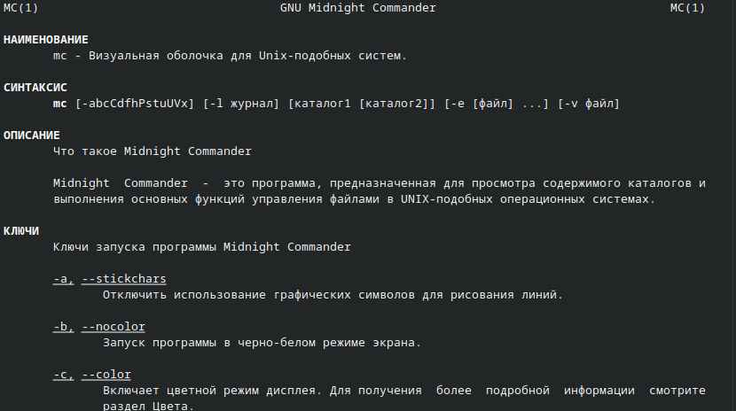

Чтение документации

## Выполнение лабораторной работы

Ввожу в терминале mc и получаю окно, в котором далее смогу работать.

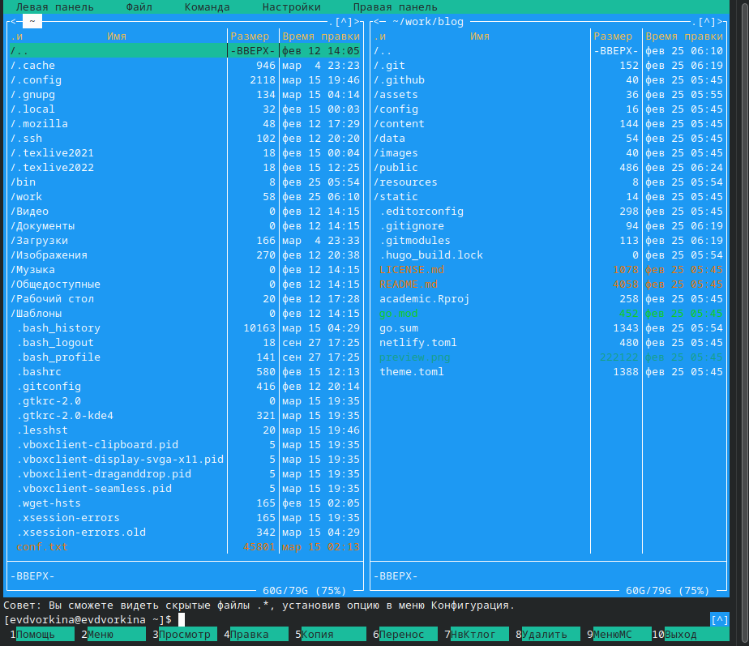

Окно mc

## Выполнение лабораторной работы

С помощью стрелочек влево вправо я могу перемещаться по директориям, а с помощью стрелочек вверх вниз перебирать файлы в директории, в которой нахожусь.

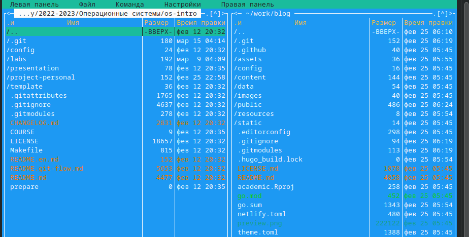

перемещение между директориями

## Выполнение лабораторной работы

С помощью F5 могу создать копию файла в выбранном каталоге/

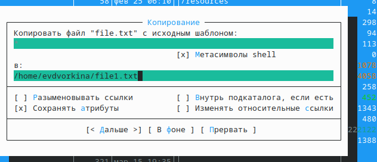

Копирование файла

## Выполнение лабораторной работы

С помощью управляющих клавиш так же можно получить информациб о правах доступа на файл и информацию о нем.

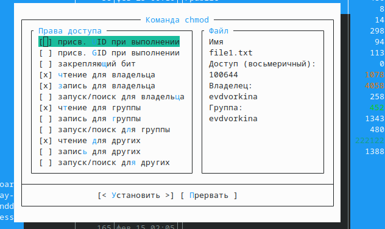

.

## Выполнение лабораторной работы

В меню правой панели вывела информацию о файле.

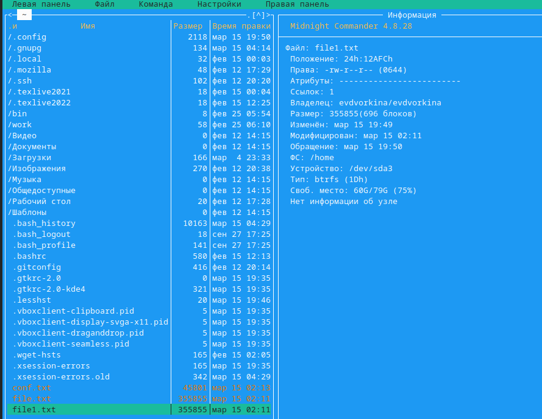

Вывод информации о файле

## Выполнение лабораторной работы

Используя возможности подменю “Файл” я просмотрела содержимое текстового файла.

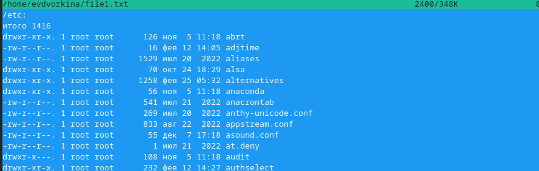

## Выполнение лабораторной работы

Открыла файл на изменение, поменяла пару строк и закрыла файл без сохранения.

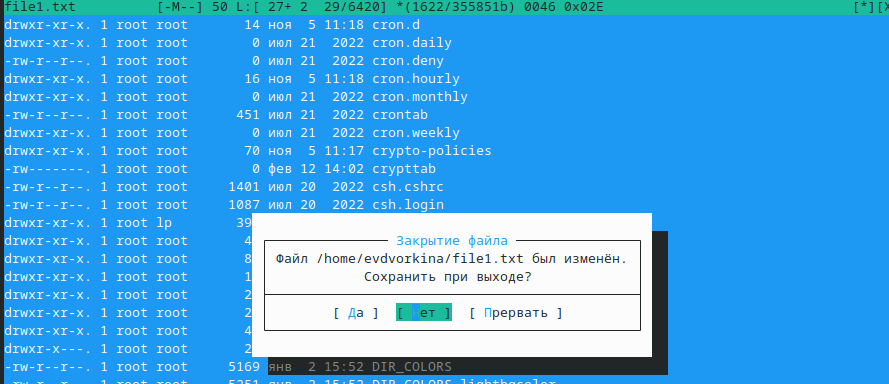

## Выполнение лабораторной работы

Создала новый каталог.

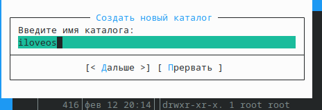

Создание нового каталога

## Выполнение лабораторной работы

Копирую файл в созданный каталог. Действия выше можно было сделать с помощью горячих клавиш.

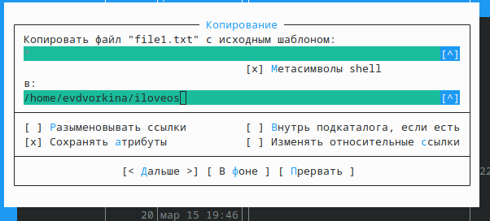

Копирование файла

## Выполнение лабораторной работы

С помощью средств подменю Команда можно найти файл с заданным условием, я искала файлы формата .txt.

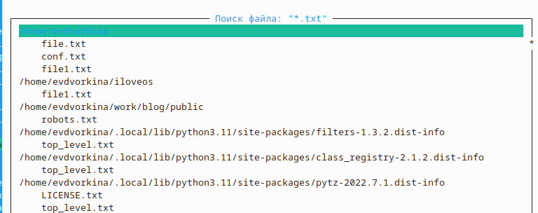

Поиск файла с фильтром

## Выполнение лабораторной работы

Можно перемещаться между директориями, я перемещусь в домашнюю.

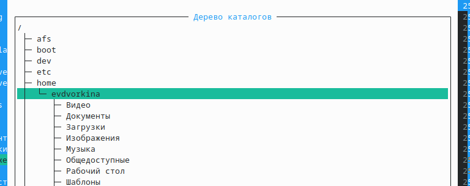

Перемещение в директорию

## Выполнение лабораторной работы

Можно использовать историю команд и применить команду из истории, я применила копирование файла.

## Выполнение лабораторной работы

Анализирую файл расширения и меню.

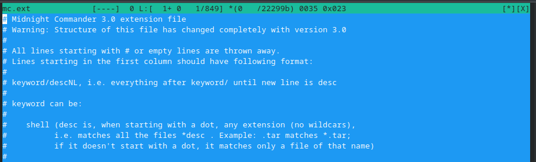

Открытие файла расширения

## Выполнение лабораторной работы

Из подменю настройки вызвала окна настройки панели, настройки внешнего вида, настройки распознавания клавиш, параметры конфигурации.

## Выполнение лабораторной работы

Командой touch text.txt создала файл.

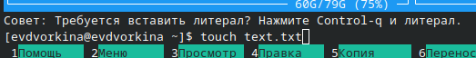

Создание файла

## Выполнение лабораторной работы

Клавишей F4 открыла файл для записи, добавила в него текст.

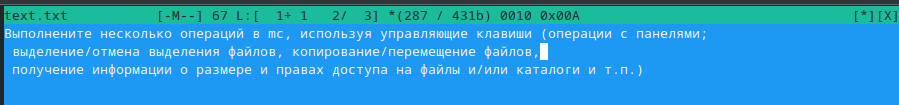

Открытие файла и запись в него

## Выполнение лабораторной работы

Выделяю текст с помощью клавиши F3 и кликов мышью.

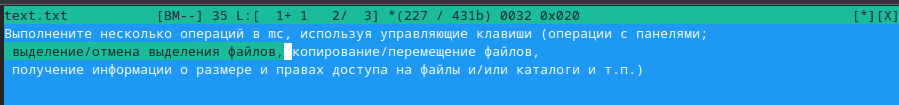

Выделение текста

## Выполнение лабораторной работы

Перемещаю выделенный текст с помощью клавиши F6.

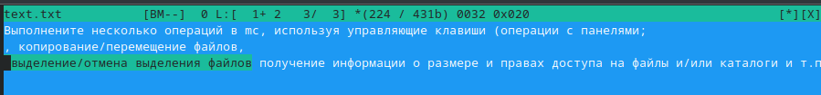

Перемещение выделенного текста

## Выполнение лабораторной работы

Удалила строку текста с помощью ctrl+y.

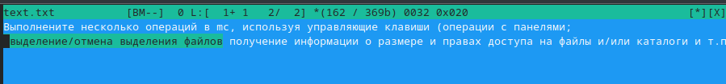

Удаление строки

## Выполнение лабораторной работы

Сохраняю изменения в файле с помощью горячей клавиши F2.

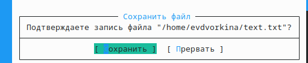

Сохранение изменений в файле

## Выполнение лабораторной работы

С помощью ctrl+u отменяю поседнее действие и возвращаю удаленную строку.

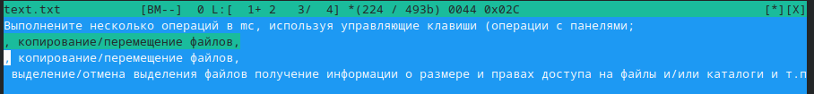

Отмена последнего действия

## Выполнение лабораторной работы

С помощью клавиш pgup pgdn у меня получилось попасть в начало и в конец файла соответственно, я добавила текст в начало и в конец файла.

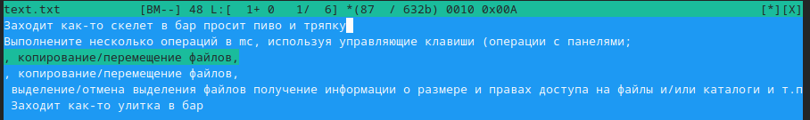

Добавление текста в начало и в конец файла

## Выполнение лабораторной работы

Горячая клавиша F10 закрывает файл, дополнительно спрашивая сохранить ли в нем несохраненные изменения, сохраняю и закрываю.

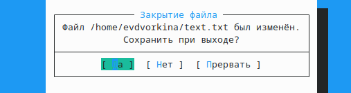

Закрытие файла с сохранением изменений

## Выполнение лабораторной работы

Открываю файл формата .cpp, с кодом на С++, встроенный редактор mc вывел его содержимое с подсветкой.

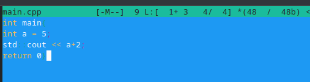

Текст файла с кодом с подсветкой

## Выполнение лабораторной работы

Я отключила подсветку и вывела снова тот же самый файл, но уже без подсветки.

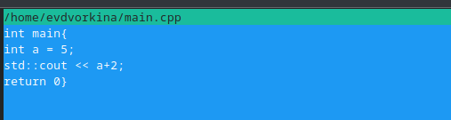

Текст файла с кодом без подсветки

# Выводы

При выполнениии данной лабораторной работы я освоила основные возможности командной оболочки Midnight Commander, приобрела навыки практической работы по просмотру каталогов и файлов; манипуляций с ними